# Tutorial18-MonteCarlo

```python
# importing the usual libraries and modules
import numpy as np
import matplotlib.pyplot as plt
```

## 2 think+type: random walks in 3D

```python
#function for a random walk in 3d with a starting posiotn the ampimt pf ste[s amd the step size

def randomWalk(p0=[0,0,0], N=50, r=0.1):

    '''

   ----------inputs-------
    p0 : list, np.array
    Three-element array indicating the starting position [x,y,z].

    N : int
    The number of steps for the random walker to take.

    r : float
    The size of each step(step size).

    -----function-------------

    Generate positions for a random walker
    that starts at some 3D position `p0`
    and takes `N` steps of length `r` in
    random directions.

    --------output-------

    positions: np.array
    An (N,3) array of the walker's position over time.
    '''

    # giving two variables the global type that I will use for numpy arrays
    global positions
    global displacement


    positions = np.zeros([N+1,3])
    #N+1 the number of steps, and the 3 represents the positoins which is a numpy array of size 3


    displacement = np.zeros(N+1)
    # I am adding a displacement array to calcu;late the distance from the starting point



    # defining x, y, and z as the initial positions
    x, y, z = p0
    p0_array = np.array(p0)

    # Setting the initial position
    positions[0] = p0.copy()


    # calculates the displacement from the origin
    displacement[0] = np.sqrt(np.square(p0_array[0]-x)+np.square(p0_array[1]-y)+np.square(p0_array[2]-z))

    for i in np.arange(N)+1:

        # Randomly generate two angles
        phi = np.random.random() * 2.0 * np.pi
        costheta = np.random.random()*2 - 1
        theta = np.arccos(costheta)
        # Increment position using mean free path (r) and angle
        x += r * np.sin(theta) * np.cos(phi)
        y += r * np.sin(theta) * np.sin(phi)
        z += r * np.cos(theta)
        # adding the new position to the array of positions
        positions[i, :] = np.array([x,y,z])
        displacement[i] = np.sqrt(np.square(p0_array[0]-x)+np.square(p0_array[1]-y)+np.square(p0_array[2]-z))

    return positions, displacement
```

```python
randomWalk(p0=[0,0,0], N=2, r=1) #testing the function with 2 steps and a step size of 1
# this should return two arrays, the first array should ve the positions array and include three numpy arrays with positions
# the second array should be the displacement array I added that should star with 0, the second value should be 1 and the third calue should be a number between 0 and 2
```

```
(array([[ 0.        ,  0.        ,  0.        ],
        [-0.77113806,  0.62906551, -0.09809525],
        [-1.52165017,  0.53482599,  0.55600756]]),
 array([0.        , 1.        , 1.70604879]))
```

```python
randomWalk(p0=[6,-8,31], N=4, r=1) # tsting the randomWalk function with a non-zero starting point
```

```
(array([[ 6.        , -8.        , 31.        ],
        [ 6.48226531, -8.02484633, 30.12432721],
        [ 5.79366867, -7.9476905 , 29.40329903],
        [ 6.28318352, -7.25284132, 29.93013851],
        [ 7.07512214, -6.64828174, 29.84445928]]),
 array([0.        , 1.        , 1.61082677, 1.33530618, 2.07805299]))
```

```python
randomWalk(p0=[10,0,-10], N=6, r=4) # changing the step size with a non-zero starting point and 6 steps
```

```
(array([[ 10.        ,   0.        , -10.        ],
        [  8.44654064,  -3.01109102,  -7.87394852],
        [  8.92968458,  -6.33941702,  -5.70858066],
        [  8.22632363,  -2.40629646,  -5.5192502 ],
        [  4.96831714,  -0.14279794,  -5.00742198],
        [  4.57590589,  -0.4942772 ,  -1.04226426],
        [  1.69902803,   1.07652116,  -3.33489731]]),
 array([ 0.        ,  4.        ,  7.72981651,  5.3864004 ,  7.08971501,
        10.48361276, 10.69993585]))
```

```python
pos0 = np.zeros(3) #making sure my function works with variable inputs
NumberSteps = 8
stepSize = 5
randomWalk(pos0,NumberSteps, stepSize) #testing inputs that are not numbers and are positional arguments rather than keyword argyuments
```

```
(array([[ 0.        ,  0.        ,  0.        ],
        [ 1.95700049, -4.04039686,  2.20121383],
        [-0.60376103, -7.23711768,  5.06887429],
        [ 0.07754727, -7.60680426,  0.12932463],
        [-4.40374386, -9.46666982,  1.33718631],
        [-8.20002449, -7.35089909, -1.13501264],
        [-4.25047589, -5.23443426, -3.35349016],
        [-2.52680194, -0.75021633, -1.96758338],
        [ 2.15525952,  0.74813481, -2.88040559]]),
 array([ 0.        ,  5.        ,  8.85629077,  7.60829872, 10.52610397,
        11.07087949,  7.53071999,  3.28921524,  3.67445039]))
```

```python
#checking to make sure my positions array and displacement array have the correct size
N = 8 +1 # most recent use for the number of times my code should have run
print(f" checking if the times my for loop ran is equal to the amount of steps I wanted, {N == len(positions) == len(displacement)}") #checking to make sre all of my arrays are the same length
```

```
 checking if the times my for loop ran is equal to the amount of steps I wanted, True
```

```python
positions.shape # this should return row, column, which in the most recent run should be something like 9, 3
```

```
(9, 3)
```

My code for the random walk function seems to be working, as the function is generating an array of arrays with length 3, and using my displacement array, it looks like the arrays are only varying by the value inputted for r. The first value in my displacement array is always zero. The second value is always r, so that means my code is working I believe!

## 3 think+write: keyword arguments

randomWalk(p0=[0,0,0], N=50, r=0.1) assigns p0, N and r as keyword arguments. While I have already tested the function assigning p0 N and r via their position, they should work regardless of where they are in the function using keyword arguments

To test this, I will run the function twice

For my first run through of the function, I will run it like using positional arguments: randomWalk([2,4,6], 8, 4) run1 = len(positions) dis1 = displacement[1]

For my second run through of the function, I will run it like using keyword arguments: randomWalk(N=8, r=4, p0=[2,4,6]) run2 = len(positions) dis2 = displacement[1]

These two runs should produce different outputs, but both runs should have the same final length of the position array, which should be N +1 = 9 for both, and the same second element [1] of the dose displacement array, which should be 4 for both. This should happen if I did the positional and keyword arguments correctly

```python
# first run using positional arguments
randomWalk([2,4,6], 8, 4)
pos1 = positions[0]
run1 = len(positions)
dis1 = round(displacement[1], 6) # one of my functions was being weird and setting distance to 3.999999999999999
```

```python
# second run using keyword arguments
randomWalk(N=8, r=4, p0=[2,4,6])
pos2 = positions[0]
run2 = len(positions)
dis2 =  round(displacement[1], 6)
```

```python
print(f"Testing if the two function inputs produced similar results: \n both functions have equal lenghts, of {run1} {run1 == run2} and, \n both functions have the same intial position of {pos1} {pos1 == pos2} and, \n both functions have equal first displacement of {dis1}, {dis1 == dis2}")
```

```
Testing if the two function inputs produced similar results:
 both functions have equal lenghts, of 9 True and,
 both functions have the same intial position of [2. 4. 6.] [ True  True  True] and,
 both functions have equal first displacement of 4.0, True
```

## 4 think+type: visualizing trajectories

```python
#plotting the random walk
pos0 = np.zeros(3)
rw = randomWalk()
stepSize = 1
plt.plot(rw[pos0, 0, ], stepSize][0] label='x')
plt.plot(rw[pos0, 1], label='y')
plt.plot(rw[pos0, 2], label='z')
plt.xlabel('Number of Scatterings')
plt.ylabel('Position')
plt.legend(loc='best');
```

```
  Cell In[112], line 5
    plt.plot(rw[pos0, 0, ], stepSize][0] label='x')
                                    ^
SyntaxError: closing parenthesis ']' does not match opening parenthesis '('
```

The code above isn't working, so I'm going to try rewriting it in my code

```python
pos0 = np.zeros(3)
rw = randomWalk()
stepSize = 1
NumberSteps = 0
randomWalk( pos0, NumberSteps, stepSize)
first_row = randomWalk( pos0, NumberSteps, stepSize)[0][0] #getting the first array from the first runthrough of the random walk
print(first_row)

NumberSteps = 1
randomWalk( pos0, NumberSteps, stepSize)
second_row = randomWalk( pos0, NumberSteps, stepSize)[0][1] #getting the first array from the second runthrough of the random walk
print(second_row)

NumberSteps = 2
randomWalk( pos0, NumberSteps, stepSize)
third_row = randomWalk( pos0, NumberSteps, stepSize)[0][2] #getting the first array from the second runthrough of the random walk
print(third_row)
print(third_row[0])
```

```
[0. 0. 0.]
[-0.69222148  0.5779951  -0.43214706]
[0.15452352 0.00681502 0.30113915]
0.1545235175920484
```

[figure not shown]

```python
#plotting the data
plt.plot( 0, first_row[0], label='x')
plt.plot( 1, second_row[0], label='y')
plt.plot( 2, third_row[0], label='z')
plt.xlabel('Number of Scatterings')
plt.ylabel('Position')
plt.legend(loc='best');
```

I cannot figure out why my plot isn't working correctly

## think+write: slicing 3D positions

#### Why does w[0,2], w[0,1] mean “the first 𝑧 position and the first 𝑦 position”?

w[0,2] means the first z position because the 0 is indexing the array w, which is the output of the function, randomWalk, and taking the first row, which is the first array of x,y,z. the 2 in w[0,2] is indexing the array x,y,z and taking the third element, which is the z element in the first row

w[0,1] means the first y position because the 0 is indexing the array w, which is the output of the function, randomWalk, and taking the first row, which is the first array of x,y,z. the 1 in w[0,1] is indexing the array x,y,z and taking the second element, which is the y element in the first row

#### what does w[:,2], w[:,1] mean?

w[:,2] should mean all of the elements in the array in all of the rows with the index position 2, which is the third column. This should refer to all of the Z elements

w[:,1] should mean all of the elements in the array in all of the rows with the index position 1, which is the second column. This should refer to all of the y elements

## 6 think+pair+code: mean distance

#### I did this by myself

Ok, so back in section 2, I already added in the displacement function to calculate the total displacement of a particle after completing it's random walk

```python
pos0 = np.zeros(3) #making sure my function works with variable inputs
NumberSteps = 1000
stepSize = 2
distance = randomWalk(pos0,NumberSteps, stepSize)[1] #getting the second return statment of displacement from my function
```

```python
print(distance)
```

```
[ 0.          2.          1.65590696 ... 65.03452527 64.16434832
 65.91116845]
```

```python
print(distance[1000]) # how far you'll be in 1000 steps of sixze 2 using random walk in 3d space
```

```
65.91116845095947
```

```python
xaxis = np.arange(0,1001,1) #defining a numpy array for the x axis
len(xaxis)
```

```
1001
```

```python
average = np.sqrt(xaxis) *2 # calculting the expected average values
```

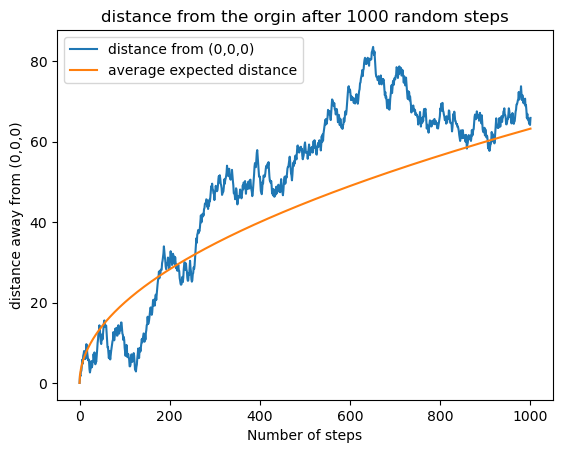

```python
plt.plot( xaxis, distance, label='distance from (0,0,0)')
plt.plot( xaxis, average, label='average expected distance')
plt.legend(loc='best');
plt.xlabel('Number of steps')
plt.ylabel('distance away from (0,0,0)')
plt.title("distance from the orgin after 1000 random steps")
```

hey at least this plot is working

1: On the first run through, the distance from (0,0,0) was below the average expected distance until about the 300th step, at which point it climbed past it and stayed above it for the rest of the simulation, ending about 20 units above the expected average distance

2: On the second run through, the distance from (0,0,0) was above the average expected distance until about the 800th step, at which point it dove below it and stayed below it for the rest of the simulation, ending about 30 units below the expected average distance

3: On the third run through, the distance from (0,0,0) was very close to the average expected distance; it varied above and below the average expected distance seven times, ending about 5 units above the expected average distance

4: On the fourth run through, the distance from (0,0,0) was above the average expected distance for essentially the entire simulation. ending about 20 units above the expected average distance

5: On the fifth run through, the distance from (0,0,0) was below the average expected distance for essentially the whole simulation, except for a spike above it from step 360 to step 400, ending about 20 units above the expected average distance

6: On the sixth run through, the distance from (0,0,0) fluctuated above and below the average expected distance greatly. It got as far below the expected average distance as at step 400, when it was about 45 units below the expected average distance. It reached its highest above the expected average at the end, ending about 20 units above the expected average distance

7: On the seventh run through, the distance from (0,0,0) was below the average expected distance for the entire simulation. it reached a minimum below the expected average distance at step 500 when it was 30 units below the expected average distance. The simulation ended about 20 units below the expected average distance

8: On the eighth run through, the distance from (0,0,0) was below the average expected distance for the entire simulation. it reached a minimum below the expected average distance at step 500 when it was 10 units below the expected average distance until the end. The simulation ended about 30 units below the expected average distance

9: On the ninth run through, the distance from (0,0,0) was oscillating between above and below the average expected distance for the entire simulation. it reached a maximum above the expected average distance at step 700 when it was 20 units above the expected average distance. The simulation ended about 30 units below the expected average distance